# DATA 7440 Final assignment

Aleksei Luchinsky, Mostafa MR

04/25/2023

# Instruction

Buskirk, DATA 7440

Final Assignment, Spring 2023

This assignment can be completed in groups of 2 to 3 students and you are encouraged to submit your assignment in groups. The assignment is worth 100 points and accounts for 40% of your final grade (taking the place of individual quizzes and a group project). Your group should submit only one final assignment and you should plan to use R for your submissions via an Rmarkdown file that generates a pdf document. Be sure to include your code chunks as part of the solution. The assignment is due via canvas submission Tuesday April 25, 2023 by 2pm.

# Problem 1

[50 Points]

We will consider the API data avaialble from the Survey package in R (see: https://cran.r-project.org/web/packages/survey/survey.pdf). The Academic Performance Index is computed for all California schools based on standardized testing of students. The data sets contain information for all schools with at least 100 students. We want to predict whether or not a school has qualified for it’s performance awards (awards) using various school, teacher and parent information. The data for this problem can be found in the apipop1.RData workspace.

## Dataset exploration

```r
rm(list = ls())
load("apipop1.RData")
```

```r
typeof(apipop_train1)
```

```
[1] "list"
```

```r
df0train = as.data.frame(apipop_train1)
head(df0train,1)
```

|  | awards | stype | meals | ell | mobility | pct.resp | not.hsg | hsg | some.col | col.grad | grad.sch | avg.ed | full | emer | enroll | api.stu |
| --- | --- | --- | --- | --- | --- | --- | --- | --- | --- | --- | --- | --- | --- | --- | --- | --- |
| 856 | No | E | 88 | 13 | 13 | 83 | 27 | 36 | 30 | 4 | 2 | 2.18 | 79 | 14 | 275 | 216 |

```r
str(df0train)
```

```
'data.frame':   4474 obs. of  16 variables:
 $ awards  : Factor w/ 2 levels "No","Yes": 1 2 1 1 1 1 2 2 2 2 ...
 $ stype   : Factor w/ 3 levels "E","H","M": 1 1 2 2 2 2 1 1 1 1 ...
 $ meals   : int  88 70 31 4 37 9 17 21 42 65 ...
 $ ell     : int  13 32 18 3 29 2 3 12 16 48 ...
 $ mobility: int  13 37 13 7 9 6 14 12 16 20 ...
 $ pct.resp: int  83 90 75 90 95 89 89 99 58 57 ...
 $ not.hsg : int  27 21 39 1 41 1 7 10 14 10 ...
 $ hsg     : int  36 37 20 8 19 13 36 35 16 26 ...
 $ some.col: int  30 33 19 19 19 29 25 18 34 27 ...
 $ col.grad: int  4 9 20 44 17 39 27 26 22 25 ...
 $ grad.sch: int  2 1 2 29 4 17 5 11 14 12 ...
 $ avg.ed  : num  2.18 2.32 2.25 3.91 2.25 ...
 $ full    : int  79 79 89 100 91 94 89 100 95 63 ...
 $ emer    : int  14 21 11 4 9 6 11 0 5 37 ...
 $ enroll  : int  275 325 990 2306 2132 1215 262 377 639 509 ...
 $ api.stu : int  216 278 809 2115 1205 1144 226 337 570 435 ...
```

```r
df0train[!complete.cases(df0train),] # To see if there is missing values
```

| awards | stype | meals | ell | mobility | pct.resp | not.hsg | hsg | some.col | col.grad | grad.sch | avg.ed | full | emer | enroll | api.stu |
| --- | --- | --- | --- | --- | --- | --- | --- | --- | --- | --- | --- | --- | --- | --- | --- |

```r
library(skimr)
skim(df0train)
```

```
── Data Summary ────────────────────────
                           Values
Name                       df0train
Number of rows             4474
Number of columns          16
_______________________
Column type frequency:
  factor                   2
  numeric                  14
________________________
Group variables            None
```

|  | skim_variable | n_missing | complete_rate | ordered | n_unique | top_counts |
| --- | --- | --- | --- | --- | --- | --- |
| 1 | awards | 0 | 1 | FALSE | 2 | Yes: 3033, No: 1441 |
| 2 | stype | 0 | 1 | FALSE | 3 | E: 3183, M: 733, H: 558 |

|  | skim_variable | n_missing | complete_rate | mean | sd | p0 | p25 | p50 | p75 | p100 | hist |
| --- | --- | --- | --- | --- | --- | --- | --- | --- | --- | --- | --- |
| 1 | meals | 0 | 1 | 47.712114 | 30.3749179 | 0 | 21.0000 | 46.00 | 74.00 | 100 | ▇▆▆▆▆ |
| 2 | ell | 0 | 1 | 22.673670 | 21.4403000 | 0 | 5.0000 | 16.00 | 35.00 | 95 | ▇▃▂▁▁ |
| 3 | mobility | 0 | 1 | 17.143719 | 11.2856395 | 0 | 11.0000 | 15.00 | 20.00 | 100 | ▇▂▁▁▁ |
| 4 | pct.resp | 0 | 1 | 77.771122 | 26.1578367 | 0 | 72.0000 | 88.00 | 95.00 | 100 | ▁▁▁▂▇ |
| 5 | not.hsg | 0 | 1 | 19.527492 | 18.5220584 | 0 | 5.0000 | 14.00 | 30.00 | 100 | ▇▃▂▁▁ |
| 6 | hsg | 0 | 1 | 24.046938 | 13.3274311 | 0 | 15.0000 | 24.00 | 31.00 | 100 | ▆▇▁▁▁ |
| 7 | some.col | 0 | 1 | 24.107734 | 10.7989168 | 0 | 17.0000 | 24.00 | 31.00 | 100 | ▅▇▁▁▁ |
| 8 | col.grad | 0 | 1 | 21.479437 | 13.8896888 | 0 | 10.0000 | 20.00 | 31.00 | 100 | ▇▆▁▁▁ |
| 9 | grad.sch | 0 | 1 | 10.854716 | 12.8641943 | 0 | 2.0000 | 6.00 | 14.00 | 100 | ▇▁▁▁▁ |
| 10 | avg.ed | 0 | 1 | 2.800948 | 0.7288505 | 1 | 2.2325 | 2.79 | 3.31 | 5 | ▂▇▇▃▁ |

[output cut: 4 more lines]

```r
typeof(apipop_test1)
```

```
[1] "list"
```

```r
df0test = as.data.frame(apipop_test1)
head(df0test,1)
```

|  | awards | stype | meals | ell | mobility | pct.resp | not.hsg | hsg | some.col | col.grad | grad.sch | avg.ed | full | emer | enroll | api.stu |
| --- | --- | --- | --- | --- | --- | --- | --- | --- | --- | --- | --- | --- | --- | --- | --- | --- |
| 3 | Yes | M | 55 | 25 | 20 | 86 | 11 | 31 | 30 | 20 | 8 | 2.82 | 80 | 12 | 546 | 472 |

```r
str(df0test)
```

```
'data.frame':   1499 obs. of  16 variables:
 $ awards  : Factor w/ 2 levels "No","Yes": 2 2 2 1 2 1 2 2 2 2 ...
 $ stype   : Factor w/ 3 levels "E","H","M": 3 3 1 2 1 1 1 3 1 3 ...
 $ meals   : int  55 10 23 3 45 59 61 8 4 10 ...
 $ ell     : int  25 10 14 8 6 13 12 3 3 3 ...
 $ mobility: int  20 11 5 40 19 10 15 6 8 13 ...
 $ pct.resp: int  86 92 91 76 84 82 86 92 75 88 ...
 $ not.hsg : int  11 2 4 6 5 9 13 1 1 2 ...
 $ hsg     : int  31 12 14 9 20 21 38 14 9 15 ...
 $ some.col: int  30 24 22 18 18 22 17 28 30 25 ...
 $ col.grad: int  20 34 37 29 16 27 13 36 32 41 ...
 $ grad.sch: int  8 28 24 37 41 22 19 22 28 18 ...
 $ avg.ed  : num  2.82 3.74 3.63 3.83 3.66 ...
 $ full    : int  80 89 91 90 87 93 100 91 100 100 ...
 $ emer    : int  12 16 9 9 4 0 0 6 0 4 ...
 $ enroll  : int  546 850 279 2370 218 298 169 765 376 1156 ...
 $ api.stu : int  472 782 272 1567 171 267 137 709 346 1006 ...
```

```r
df0test[!complete.cases(df0test),] # To see if there is missing values
```

| awards | stype | meals | ell | mobility | pct.resp | not.hsg | hsg | some.col | col.grad | grad.sch | avg.ed | full | emer | enroll | api.stu |
| --- | --- | --- | --- | --- | --- | --- | --- | --- | --- | --- | --- | --- | --- | --- | --- |

```r
library(skimr)
skim(df0test)
```

```
── Data Summary ────────────────────────
                           Values
Name                       df0test
Number of rows             1499
Number of columns          16
_______________________
Column type frequency:
  factor                   2
  numeric                  14
________________________
Group variables            None
```

|  | skim_variable | n_missing | complete_rate | ordered | n_unique | top_counts |
| --- | --- | --- | --- | --- | --- | --- |
| 1 | awards | 0 | 1 | FALSE | 2 | Yes: 997, No: 502 |
| 2 | stype | 0 | 1 | FALSE | 3 | E: 1046, M: 264, H: 189 |

|  | skim_variable | n_missing | complete_rate | mean | sd | p0 | p25 | p50 | p75 | p100 | hist |
| --- | --- | --- | --- | --- | --- | --- | --- | --- | --- | --- | --- |
| 1 | meals | 0 | 1 | 47.793863 | 30.4017745 | 0 | 21.00 | 45.00 | 75.00 | 100.0 | ▇▇▆▆▇ |
| 2 | ell | 0 | 1 | 22.679787 | 21.3671931 | 0 | 5.00 | 16.00 | 34.00 | 94.0 | ▇▃▂▁▁ |
| 3 | mobility | 0 | 1 | 16.938626 | 10.3871761 | 1 | 11.00 | 15.00 | 20.00 | 100.0 | ▇▂▁▁▁ |
| 4 | pct.resp | 0 | 1 | 77.604403 | 25.9772984 | 0 | 73.00 | 88.00 | 95.00 | 100.0 | ▁▁▁▂▇ |
| 5 | not.hsg | 0 | 1 | 20.046031 | 19.2608027 | 0 | 5.00 | 14.00 | 31.00 | 100.0 | ▇▃▂▁▁ |
| 6 | hsg | 0 | 1 | 24.282855 | 13.3877689 | 0 | 16.00 | 24.00 | 31.00 | 100.0 | ▆▇▁▁▁ |
| 7 | some.col | 0 | 1 | 24.264843 | 11.2360834 | 0 | 17.00 | 25.00 | 32.00 | 100.0 | ▅▇▁▁▁ |
| 8 | col.grad | 0 | 1 | 21.026017 | 13.9092516 | 0 | 10.00 | 20.00 | 30.00 | 100.0 | ▇▆▁▁▁ |
| 9 | grad.sch | 0 | 1 | 10.390260 | 12.4872351 | 0 | 2.00 | 6.00 | 14.00 | 80.0 | ▇▁▁▁▁ |
| 10 | avg.ed | 0 | 1 | 2.774356 | 0.7351736 | 1 | 2.22 | 2.77 | 3.25 | 4.7 | ▂▆▇▅▂ |

[output cut: 4 more lines]

## Part 1

Using the information in the apipop_train1 dataset within the apipop1.RData workspace:

### a.

construct a LASSO model that predicts whether or not a school qualified for it’s award program. Use 5-fold cross validation on the apipop_train1 dataset to determine the penalty parameter and specify the seed 7440 prior to running the model.

```r
# Using caret to perform regularized regression
library(caret)
RNGkind (sample.kind = "Rounding")
set.seed(7440)
train_control <- trainControl(method="cv", number=5)

#########################
### Lasso regression ####
#########################

glmnet.lasso <- train(awards ~ .,
                      data = df0train,
                      method = "glmnet",
                      trControl = train_control,
                      tuneGrid = expand.grid(alpha = 1,
                                             lambda = seq(0.001,0.1,by = 0.001)
                                             )
                      )

glmnet.lasso
```

```
glmnet

4474 samples
  15 predictor
   2 classes: 'No', 'Yes'

No pre-processing
Resampling: Cross-Validated (5 fold)
Summary of sample sizes: 3579, 3580, 3579, 3579, 3579
Resampling results across tuning parameters:

  lambda  Accuracy   Kappa
  0.001   0.7069729  0.223202350
  0.002   0.7085371  0.226570587
  0.003   0.7071958  0.221039658
  0.004   0.7069729  0.218584926
  0.005   0.7065262  0.215761476
  0.006   0.7058558  0.212800092
  0.007   0.7060790  0.210801313
  0.008   0.7056313  0.207190084
  0.009   0.7058548  0.205220294
  0.010   0.7056316  0.203449956
  0.011   0.7060790  0.202943354
  0.012   0.7065259  0.202782181
  0.013   0.7056318  0.197201535
  0.014   0.7047377  0.192659859
  0.015   0.7051847  0.191038936
  0.016   0.7045145  0.187291228
  0.017   0.7051847  0.187121160
  0.018   0.7056321  0.186239603
  0.019   0.7049617  0.182376377
  0.020   0.7049619  0.180529481
  0.021   0.7040676  0.176244951
  0.022   0.7040673  0.174423296
  0.023   0.7033969  0.168965160
  0.024   0.7033969  0.167146811
  0.025   0.7018327  0.160659222
  0.026   0.7004922  0.154616533
  0.027   0.6980338  0.145105760
  0.028   0.6975866  0.141553010
```

[output cut: 61 more lines]

```
  0.090   0.6779168  0.000000000
  0.091   0.6779168  0.000000000
  0.092   0.6779168  0.000000000
  0.093   0.6779168  0.000000000
  0.094   0.6779168  0.000000000
  0.095   0.6779168  0.000000000
  0.096   0.6779168  0.000000000
  0.097   0.6779168  0.000000000
  0.098   0.6779168  0.000000000
  0.099   0.6779168  0.000000000
  0.100   0.6779168  0.000000000

Tuning parameter 'alpha' was held constant at a value of 1
Accuracy was used to select the optimal model using the largest value.
The final values used for the model were alpha = 1 and lambda = 0.002.
```

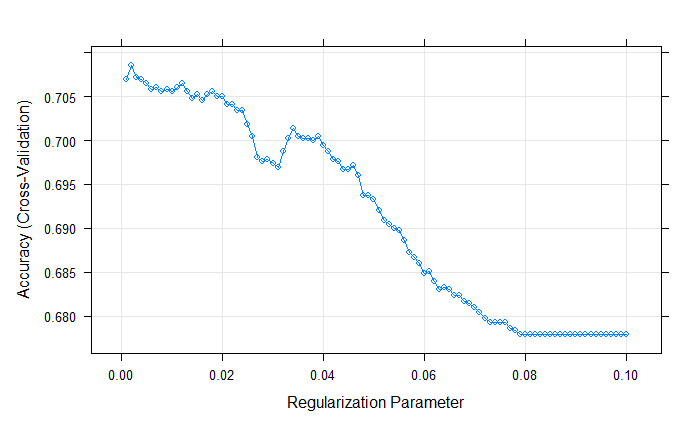

```r
plot(glmnet.lasso)
```

```r
# best parameter
glmnet.lasso$bestTune
```

|  | alpha | lambda |
| --- | --- | --- |
| 2 | 1 | 0.002 |

```r
# best coefficient
lasso.model <- coef(glmnet.lasso$finalModel, glmnet.lasso$bestTune$lambda)
lasso.model
```

```
17 x 1 sparse Matrix of class "dgCMatrix"
                       s1
(Intercept)  0.8926504012
stypeH      -1.5845284588
stypeM      -0.8623349426
meals       -0.0092839828
ell          0.0007901789
mobility     .
pct.resp     .
not.hsg      .
hsg         -0.0060595502
some.col    -0.0034427460
col.grad     .
grad.sch     0.0088978435
avg.ed       .
full         0.0099025538
emer         0.0079312629
enroll      -0.0002176826
api.stu      .
```

### b.

Now apply a one rule algorithm to determine the feature that most explains the award outcomes.

### c.

Now apply a sequential covering algorithm to expand the rule set derived in B.

### d.

Now apply a rule-fit algorithm to determine features and possible interaction effects that are important for explaining award qualification. For this model set the seed to be 2021 and also use 5 folds.

## Part 2

Using the respective models create a table that provides overall accuracy, sensitivity and specificity for predicting if a school qualified for its awards program using the apipop_test1 as the test set for each of the models you derived in parts a-d of Part 1.

```r
### Confusion matrix

# Notes:
# 1. type = "responcse" or "class" or "raw" or "prob".
# 2. positive = "1" or "yes" or "any other thing based on the response levels for example 'A' ".
# 3. df$colname: Rewrite the response column name.
# 4. pred.prob[,2]: We may need to select the second (positive) column of the prediction.

# prediction on test data
pred.prob.test <- predict(glmnet.lasso,
                      s = glmnet.lasso$bestTune,
                      newdata = df0test,
                      type = "prob"
                      )
pred.y.test <- ifelse(pred.prob.test[,2] > 0.5, "Yes", "No") # using cutoff = 0.5
confusionMatrix(as.factor(pred.y.test), as.factor(df0test$awards), positive = "Yes")
```

```
Confusion Matrix and Statistics

          Reference
Prediction  No Yes
       No  148  74
       Yes 354 923

               Accuracy : 0.7145
                 95% CI : (0.6909, 0.7372)
    No Information Rate : 0.6651
    P-Value [Acc > NIR] : 2.317e-05

                  Kappa : 0.2561

 Mcnemar's Test P-Value : < 2.2e-16

            Sensitivity : 0.9258
            Specificity : 0.2948
         Pos Pred Value : 0.7228
         Neg Pred Value : 0.6667
             Prevalence : 0.6651
         Detection Rate : 0.6157
   Detection Prevalence : 0.8519
      Balanced Accuracy : 0.6103

       'Positive' Class : Yes
```

## Part 3

For every model for which it is appropriate, derive the variable importance measures (feature specific importances, not rule specific importances) and create another table that lists the top 4 most important features for predicting whether a school qualified for it’s award program.

For rule fit, provide the graphs that illustrate the top three most important RULES.

Comment on where there are consistencies in the most important features and where there aren’t. Which model gives you the best sense of what is going on between the features and qualifying for the awards programs.

## Part 4

Now compute a random forest model to predict whether or not a school qualifies for its awards program (using the training data: apipop_train1) with 750 trees and default value of the mtry parameter. Prior to running the model, set the seed to be 429.

```r
#dev.copy2pdf(file = "E:/Data mining/Lecture Notes/plots/ct3.pdf")
rf$finalModel
```

```
Call:
 randomForest(x = x, y = y, ntree = 750, mtry = param$mtry)
               Type of random forest: classification
                     Number of trees: 750
No. of variables tried at each split: 2

        OOB estimate of  error rate: 28.01%
Confusion matrix:
     No  Yes class.error
No  452  989  0.68632894
Yes 264 2769  0.08704253
```

```r
# get prediction on the test data
pred.test.rf = predict(rf$finalModel,
                       newdata = df0test,
                       type = 'class'
                       )
```

[output not shown]

Using your model:

### a.

create an overall interaction plot that displays the overall H statistic for each of the features.

### b.

Using the feature with the highest overall H statistic, create an additional plot that shows the H statistics related to this specific feature.

### c.

Is the information in the second plot consistent with the some of the rules the Rule Fit model is reporting? Why or why not?

### d.

What is the H-statistic value corresponding to the variables included in the top-most important rule in the rule fit model that involves only two predictors? (Be sure to indicate what the top-most important rule with two features is from your rule fit model, along with it’s importance) as well as the plot of that rule from the RuleFit model.

# Problem 2

[50 points]

We will use the api data again for this problem, but this time we are interested in predicting the api test scores for 2000 (i.e. api00) based on a battery of school, teacher and parent information. This time the data and models are available in the apipopProb2.RData R workspace. Note the data sets here are different than for Problem 1.

For this problem, you are given three models that aim at predicting api00 (R objects model1 – model3), using different methods (i.e., CART, XGBoost, OLS regression). Utilize the following interpretation techniques with the training data to learn more about how those models were trained. Specifically for each of the models you should:

## a.

Produce Partial Dependence plots for the most important predictor of each model.

## b.

Produce Partial Dependence plots for the two most important predictors of each model (i.e., 3D plots or heatmaps or contour plots).

## c.

Produce Accumulated Local Effects plots for the most important predictor in each model. How do these plots vary from those produced in part b? Given the correlation structure in the apipop_train data is it surprising or not that these plots differ or are similar to each other.

## d.

Compute the overall interaction H statistics as well as the feature specific statistics for the ELL variable for all of the models. Provide a table that includes as rows the predictors in the apipop_train data file and the H statistics for each model as columns. For the ELL specific H statistics, provide an interaction plot per model.

## e.

Evaluate the prediction performance of each model using the test set that is included in the workspace (e.g. apipop_test).

## f.

Considering the results for the tasks above, which model object belongs to which method? Explain your choice!